# SDS/CSC 293 Mini-Project 2: Multiple Regression

Group 24: Jocelyn Jingjing Hu and Jasmine Pacheco-Ramos

Wednesday, March 6<sup>th</sup>, 2019

You will be submiting an entry to Kaggle’s [House Prices: Advanced Regression Techniques](https://www.kaggle.com/c/house-prices-advanced-regression-techniques/) by fitting a **multiple regression** model $\hat{f}(x)$.

# EDA

Read in data provided by Kaggle for this competition. They are organized in the `data/` folder of this RStudio project:

```r
#import datasets
training <- read_csv("~/SDS293/mp2/data/train.csv")
test <- read_csv("~/SDS293/mp2/data/test.csv")
sample_submission <- read_csv("~/SDS293/mp2/data/sample_submission.csv")
```

Before performing any model fitting, you should always conduct an exploratory data analysis. This will help guide and inform your model fitting.

## Look at your data!

Always, ALWAYS, **ALWAYS** start by looking at your raw data. This gives you visual sense of what information you have to help build your predictive models. To get a full description of each variable, read the data dictionary in the `data_description.txt` file in the `data/` folder.

Note that the following code chunk has `eval = FALSE` meaning “don’t evaluate this chunk with knitting” because `.Rmd` files won’t knit if they include a `View()`:

```r
View(training)
glimpse(training)

View(test)
glimpse(test)
```

In particular, pay close attention to the variables and variable types in the `sample_submission.csv`. Your submission must match this exactly.

```r
#glimpse sample_submission and see which variables in training contan NAs
glimpse(sample_submission)
```

```
## Observations: 1,459
## Variables: 2
## $ Id        <dbl> 1461, 1462, 1463, 1464, 1465, 1466, 1467, 1468, 1469...
## $ SalePrice <dbl> 169277.1, 187758.4, 183583.7, 179317.5, 150730.1, 17...
```

```r
na_count <-sapply(training, function(y) sum(length(which(is.na(y)))))
na_count <- data.frame(na_count)
```

## Data wrangling

As much as possible, try to do all your data wrangling here:

```r
# select variables
training <- training %>%
  select(Id, GrLivArea, CentralAir,SalePrice,ExterQual,LotShape,TotRmsAbvGrd,LotArea, HouseStyle) %>%
  mutate(airtype= ifelse(CentralAir == "Y", 1 , 2))

test <- test %>%
 select(Id, GrLivArea,CentralAir,ExterQual,LotShape,TotRmsAbvGrd,LotArea,HouseStyle) %>%
  mutate(airtype= ifelse(CentralAir == "Y", 1 , 2))

#transform categorical vars type to factor
training$airtypef <- factor(training$airtype)
training$ExterQualf <- factor(training$ExterQual)
training$LotShapef <- factor(training$LotShape)
training$HouseStylef <- factor(training$HouseStyle)

test$airtypef <- factor(test$airtype)
test$ExterQualf <- factor(test$ExterQual)
test$HouseStylef<- factor(test$HouseStyle)
test$LotShapef <- factor(test$LotShape)

#log numerical variables
training <- training %>%
  mutate(log10_GrLivArea = log10(GrLivArea))%>%
  mutate(log10_TotRmsAbvGrd = log10(TotRmsAbvGrd))%>%
  mutate(log10_LotArea = log10(LotArea))%>%
  mutate(log10_SalePrice = log10(SalePrice))

test <- test %>%
  mutate(log10_GrLivArea = log10(GrLivArea))%>%
  mutate(log10_TotRmsAbvGrd = log10(TotRmsAbvGrd))%>%
  mutate(log10_LotArea = log10(LotArea))

#Randomly reorder the rows and split them into five folds
training <- training %>%
  sample_frac(1) %>%
  mutate(fold = rep(1:5, length = n())) %>%
  arrange(fold)
```

[^1]

# Minimally viable product

## Model fitting

```r
meanRMLSE <- tibble(
 nfold=c(1:5),
 meanRMLSE=0
)

  RMLSE <- rep(0, 5)
  for(j in 1:5){
    pretend_training <- training %>%
      filter(fold != j)
    pretend_test <- training %>%
      filter(fold == j)

    # Fit a regression model fˆ1 using one arbitrarily chosen numerical predictor and one arbitrarily chosen categorical predictor.
    model_0_formula <- as.formula("log10_SalePrice ~ log10_GrLivArea + airtypef ")
    model_0 <- lm(model_0_formula, data = pretend_training)

    model_0 %>%
      broom::tidy(conf.int = TRUE)

    # Extract point-by-point info of points used to fit model
    fitted_points_0 <- model_0 %>%
    broom::augment()
    fitted_points_0

    # Extract model summary info
    model_0 %>%
      broom::glance()

    # Make predictions on pretend test data
    predicted_points_0 <- model_0 %>%
      broom::augment(newdata = pretend_test)%>%
      as_tibble()


    # Save predictions in pretend_test data frame
    pretend_test <- pretend_test %>%
      mutate(
        log10_SalePrice_hat = predicted_points_0$.fitted,
        SalePrice_hat = 10^log10_SalePrice_hat
      )

    # RMLSE[j] means row j in RMLSE
    RMLSE[j] <- pretend_test %>%
      mutate(
        residual = log(SalePrice + 1) - log(SalePrice_hat + 1),
        residual_sq = residual^2
      ) %>%
      summarize(
        MLSE = mean(residual_sq),
        RMLSE = sqrt(MLSE)
      ) %>%
      pull(RMLSE)

  }
```

## Estimate of your Kaggle score

```r
#RMLSE estimation
meanRMLSE$meanRMLSE[1]<- mean(RMLSE)
meanRMLSE$RMLSE<-RMLSE
print(meanRMLSE$meanRMLSE[1])
```

```
## [1] 0.2531728
```

## Create your submission CSV

```r
predicted_points_0 <- model_0 %>%
      broom::augment(newdata = test)%>%
      as_tibble()

# Save predictions in the test data frame
test0 <- test %>%
  mutate(
    log10_SalePrice_hat = predicted_points_0$.fitted,
    SalePrice_hat = 10^log10_SalePrice_hat
  )
submission <- sample_submission %>%
  mutate(SalePrice = test0$SalePrice_hat)

write_csv(submission, path = "~/SDS293/mp2/data/submission_due_diligence.csv")
```

## Screenshot of your Kaggle score

Our score based on our submission’s “Root Mean Squared Logarithmic Error” was 0.26985.

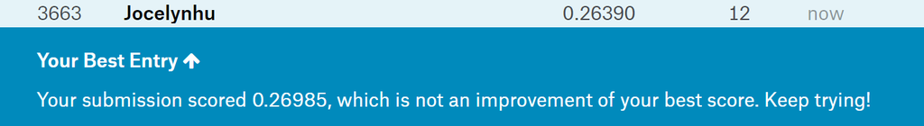

# Due diligence

## Comparisons of estimated scores and Kaggle scores

Our estimated RMLSE: 0.25317 Kaggle RMLSE: 0.26985

# Reaching for the stars

## Model fitting

```r
meanRMLSE <- tibble(
 nfold=c(1:5),
 meanRMLSE=0
)

  RMLSE <- rep(0, 5)
  for(j in 1:5){
    pretend_training <- training %>%
      filter(fold != j)
    pretend_test <- training %>%
      filter(fold == j)

    # Fit a regression model 1 using one arbitrarily chosen numerical predictor and one arbitrarily chosen categorical predictor
    model_1_formula <- as.formula("log10_SalePrice ~ log10_GrLivArea  + log10_TotRmsAbvGrd + log10_LotArea + LotShapef + ExterQualf + airtypef ")
    model_1 <- lm(model_1_formula, data = pretend_training)

    model_1 %>%
      broom::tidy(conf.int = TRUE)

    # Extract point-by-point info of points used to fit model
    fitted_points_1 <- model_1 %>%
     broom::augment()
    fitted_points_1

    # Extract model summary info
  model_1 %>%
    broom::glance()

    # Make predictions on pretend test data.
    predicted_points_1 <- model_1 %>%
      broom::augment(newdata = pretend_test)%>%
      as_tibble()


    # Save predictions in pretend_test data frame
    pretend_test <- pretend_test %>%
      mutate(
        log10_SalePrice_hat = predicted_points_1$.fitted,
        SalePrice_hat = 10^log10_SalePrice_hat,
        is_na=is.na(SalePrice_hat)
      )

    # RMLSE[j] means row j in RMLSE
    RMLSE[j] <- pretend_test %>%
      mutate(
        residual = log(SalePrice + 1) - log(SalePrice_hat + 1),
        residual_sq = residual^2) %>%
      summarize(
        MLSE = mean(residual_sq),
        RMLSE = sqrt(MLSE)) %>%
        pull(RMLSE)


  }
```

## Estimate of your Kaggle score

```r
#RMLSE estimation
meanRMLSE$meanRMLSE[1]<- mean(RMLSE)
meanRMLSE$RMLSE<-RMLSE
print(meanRMLSE$meanRMLSE[1])
```

```
## [1] 0.1993263
```

## Create your submission CSV

```r
predicted_points_1 <- model_1 %>%
      broom::augment(newdata = test)%>%
      as_tibble()

# Save predictions in the test data frame
test1 <- test %>%
  mutate(
    log10_SalePrice_hat = predicted_points_1$.fitted,
    SalePrice_hat = 10^log10_SalePrice_hat
  )
submission <- sample_submission %>%
  mutate(SalePrice = test1$SalePrice_hat)

write_csv(submission, path = "~/SDS293/mp2/data/submission_reach_for_stars.csv")
```

## Screenshot of your Kaggle score

Our score based on our submission’s “Root Mean Squared Logarithmic Error” was 0.21592.

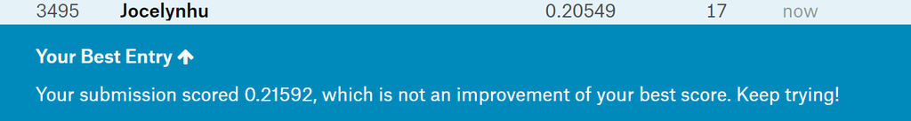

## Comparisons of estimated scores and Kaggle scores

Our estimated RMLSE: 0.199 Kaggle RMLSE: 0.216

# Point of diminishing returns

```r
#datasets for forward stepwise selection
training <- training %>%
  select(log10_GrLivArea, airtypef,log10_SalePrice,ExterQualf,LotShapef,log10_TotRmsAbvGrd,log10_LotArea)
test <- test %>%
  select(log10_GrLivArea, airtypef,ExterQualf,LotShapef,log10_TotRmsAbvGrd,log10_LotArea)
sum(is.na(training))
```

```
## [1] 0
```

```r
#prediction function
predict.regsubsets =function (object , newdata ,id ,...){
form=as.formula (object$call [[2]])
mat=model.matrix(form ,newdata )
coefi=coef(object ,id=id)
xvars=names(coefi)
mat[,xvars]%*%coefi
}

#use cross validation approach for the best j-variable model
k=5
set.seed(1)
folds=sample (1:k,nrow(training),replace=TRUE)
cv.errors =matrix (NA,k,6, dimnames =list(NULL , paste (1:6) ))
  for(j in 1:k){
  best.fit=regsubsets (log10_SalePrice∼.,data=training [folds!=j,],
    nvmax=6)
  for(i in 1:6){
  pred=predict (best.fit ,training [folds ==j,],id=i)
  cv.errors[j,i]= mean( ( training$log10_SalePrice[folds==j]-pred)^2)
    }
  }

mean.cv.errors=apply(cv.errors ,2, mean)
mean.cv.errors
```

```
##           1           2           3           4           5           6
## 0.014058136 0.010756777 0.009214331 0.008461394 0.008018827 0.007617434
```

```r
which.min(mean.cv.errors)
```

```
## 6
## 6
```

```r
#actual equation for the 6-var model
reg.best=regsubsets (Salary∼.,data=Hitters, nvmax=6)
coef(reg.best,6)
```

[output not shown]

## Create your submission CSV

```r
#same as the csv from reaching for star
predicted_points_1 <- model_1 %>%
      broom::augment(newdata = test)%>%
      as_tibble()

test1 <- test %>%
  mutate(
    log10_SalePrice_hat = predicted_points_1$.fitted,
    SalePrice_hat = 10^log10_SalePrice_hat
  )
submission <- sample_submission %>%
  mutate(SalePrice = test1$SalePrice_hat)

write_csv(submission, path = "~/SDS293/mp2/data/submission_deminishing_returns.csv")
```

## Screenshot of your Kaggle score

Our score based on our submission’s “Root Mean Squared Logarithmic Error” was 0.21592.

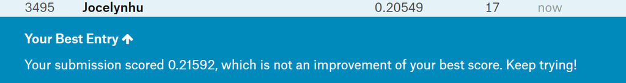

## Comparisons of estimated scores and Kaggle scores

Our estiamted RMLSE: 0.199 Kaggle RMLSE: 0.216

[^1]: This is my [source](https://stats.idre.ucla.edu/r/modules/coding-for-categorical-variables-in-regression-models/)